# Practical Machine Learning

Brett Taylor

October 11, 2015

The goal of this project is to predict the manner in which we did the exercise. This is the “classe” variable in the training set.

Outcome: classe

# Steps

## Choosing the predictor variables

I identified that there are a lot of variables in the training set that have a significant amount of missing values. These varirables were removed by using the cleanData() function {see Appendix: Code}. In addition, the first 7 variables in the training set were removed. These were removed because they would bias the model since they are attributes associated with the testing process, and are not related to the actual methods of sensor measurement. The rest of the varialbles obtained from the sensors were utilized which accounted for 52 variables.

## Building the data set

I created a function called #buildData() {see Appendix: Code} which loads, cleans and writes the data sets. I also had to remove an observation that had the value “4” in the classe factor variable, and refactor it. The buildData() function also separates the pml_training.csv file into 2 data sets: training - 75% & validation 25%. The buildData function allows you to choose “quickRun = TRUE” which will take a very small sampling of the data so that you can test the code prior to fulling building out the model.

```r
source("buildData.R")
buildData(quickRun = FALSE)
training <- read.csv("./data/training.csv")
validation <- read.csv("./data/validation.csv")
testing <- read.csv("./data/pml-testing.csv")
```

## Create a Model

Each of these work well with category based outcomes. Each model utilizes the same training set, and has the same seed set so that validation of accuracy can be performed.

```r
source("buildModelGbm.R")
source("buildModelSvm.R")
source("buildModelRfm.R")

#buildModels
source("buildData.R")
fast = FALSE
buildData(quickRun=fast)
message("load buildModelGbm.R")
source("buildModelGbm.R")
training <- read.csv("./data/training.csv")
message("run buildGbm()")
gmbFit <- buildGbm(quickRun =fast,runInParallel=TRUE,cores=4,data=training)
source("buildModelSvm.R")
svmFit <- buildSvm(quickRun =fast,runInParallel=TRUE,cores=4,data=training)
source("buildModelRfm.R")
rfmFit <- buildRfm(quickRun =fast,runInParallel=TRUE,cores=4,data=training)
```

```
## Stochastic Gradient Boosting
##
## 14717 samples
##    52 predictor
##     5 classes: 'A', 'B', 'C', 'D', 'E'
##
## No pre-processing
## Resampling: Cross-Validated (10 fold, repeated 10 times)
## Summary of sample sizes: 13246, 13244, 13246, 13244, 13245, 13246, ...
## Resampling results across tuning parameters:
##
##   interaction.depth  n.trees  Accuracy   Kappa      Accuracy SD
##   1                   50      0.7501856  0.6832605  0.012401990
##   1                  100      0.8205062  0.7728238  0.009821499
##   1                  150      0.8547867  0.8162483  0.008625903
##   2                   50      0.8569267  0.8187158  0.009071903
##   2                  100      0.9098935  0.8859689  0.007623948
##   2                  150      0.9346945  0.9173568  0.006121004
##   3                   50      0.8994967  0.8727623  0.008598230
##   3                  100      0.9452535  0.9307243  0.006278689
##   3                  150      0.9628862  0.9530447  0.004923946
##   Kappa SD
##   0.015825914
##   0.012456799
##   0.010926396
##   0.011538625
##   0.009653934
##   0.007749555
##   0.010885150
##   0.007943840
##   0.006231695
##
## Tuning parameter 'shrinkage' was held constant at a value of 0.1
##
## Tuning parameter 'n.minobsinnode' was held constant at a value of 10
## Accuracy was used to select the optimal model using  the largest value.
## The final values used for the model were n.trees = 150,
##  interaction.depth = 3, shrinkage = 0.1 and n.minobsinnode = 10.
```

```
## Support Vector Machines with Radial Basis Function Kernel
```

```
## 14717 samples
##    52 predictor
##     5 classes: 'A', 'B', 'C', 'D', 'E'
##
## Pre-processing: centered, scaled
## Resampling: Cross-Validated (10 fold, repeated 3 times)
## Summary of sample sizes: 13245, 13246, 13246, 13245, 13246, 13245, ...
## Resampling results across tuning parameters:
##
##   C      Accuracy   Kappa      Accuracy SD  Kappa SD
##    0.25  0.7839905  0.7244892  0.009932242  0.01275289
##    0.50  0.7997105  0.7448843  0.009503676  0.01219586
##    1.00  0.8097428  0.7579977  0.009549987  0.01222670
##    2.00  0.8119636  0.7609363  0.010324806  0.01318091
##    4.00  0.8172644  0.7677114  0.010155060  0.01294725
##    8.00  0.8225188  0.7743750  0.010643742  0.01358242
##   16.00  0.8330061  0.7877163  0.011292639  0.01440776
##   32.00  0.8366077  0.7923133  0.011281156  0.01440122
##
## Tuning parameter 'sigma' was held constant at a value of 0.0128836
## Accuracy was used to select the optimal model using  the largest value.
## The final values used for the model were sigma = 0.0128836 and C = 32.
```

```
## Random Forest
##
## 14717 samples
##    52 predictor
##     5 classes: 'A', 'B', 'C', 'D', 'E'
##
## No pre-processing
## Resampling: Cross-Validated (10 fold, repeated 10 times)
## Summary of sample sizes: 13246, 13246, 13244, 13245, 13245, 13246, ...
## Resampling results across tuning parameters:
##
##   mtry  Accuracy   Kappa      Accuracy SD  Kappa SD
##    2    0.9927159  0.9907852  0.002389659  0.003023339
##   27    0.9929198  0.9910434  0.002655760  0.003359718
##   52    0.9861995  0.9825413  0.003856425  0.004879245
##
## Accuracy was used to select the optimal model using  the largest value.
## The final value used for the model was mtry = 27.
```

## Performance of Computing

| model_type | runInParallel | cores | user | system | elapsed |
| --- | --- | --- | --- | --- | --- |
| svmRadial | FALSE | 1 | 199.7 | 203.5 | 12210.3 |
| svmRadial | TRUE | 1 | 137.5 | 137.4 | 8246.9 |
| gbm | TRUE | 4 | 0.6 | 34.5 | 2070.7 |
| svmRadial | TRUE | 4 | 0.5 | 73.6 | 4417.4 |
| rf | TRUE | 4 | 1.1 | 105.6 | 6336.6 |
| gbm | FALSE | 4 | 103.4 | 106.0 | 6360.3 |
| svmRadial | FALSE | 4 | 160.0 | 198.5 | 11910.6 |
| rf | FALSE | 4 | 284.9 | 288.0 | 17280.3 |

## Cross Validation

This demonstrates the amount of cross validation performed by each of the 3 models.

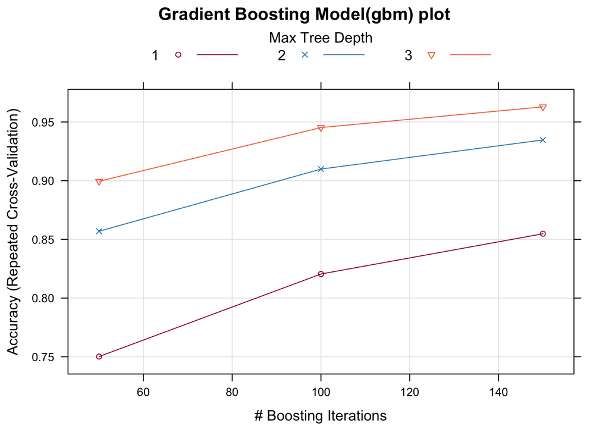

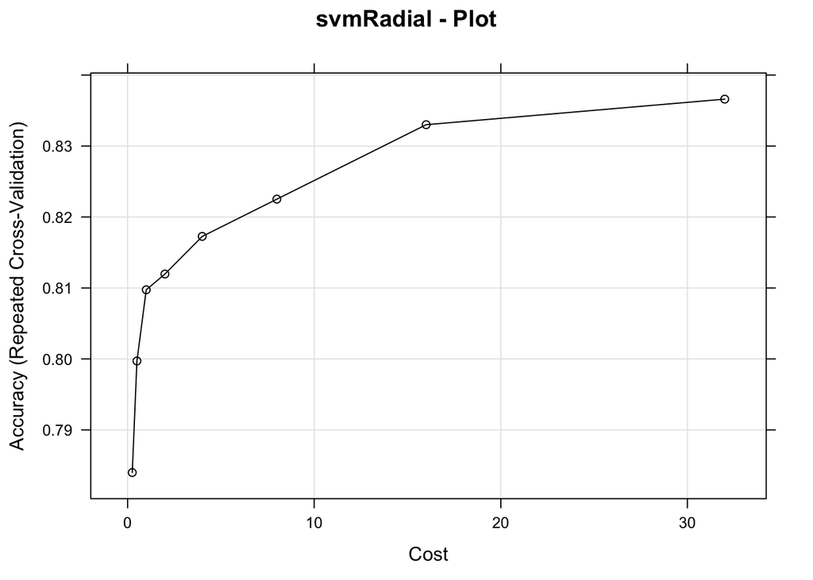

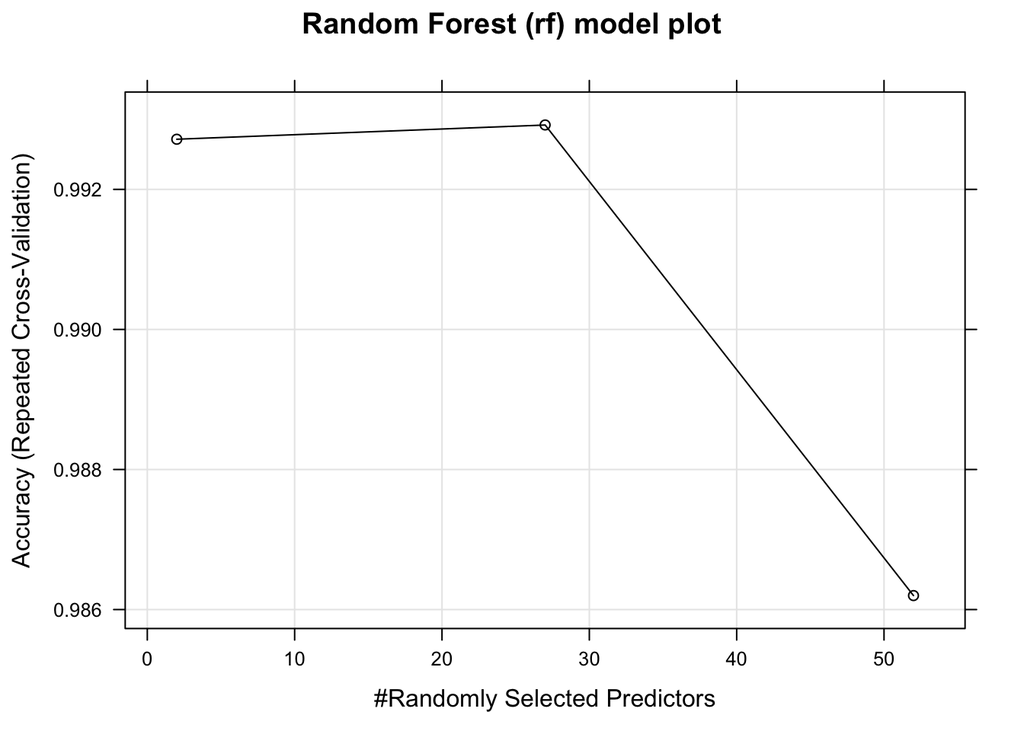

## Confusion Matricies

### GBM Model Predication Validation

```
## Confusion Matrix and Statistics
##
##           Reference
## Prediction    A    B    C    D    E
##          A 1369   38    0    1    0
##          B   22  884   25    3    5
##          C    2   27  816   38    8
##          D    0    0   12  751   13
##          E    2    0    2   11  875
##
## Overall Statistics
##
##                Accuracy : 0.9574
##                  95% CI : (0.9513, 0.9629)
##     No Information Rate : 0.2845
##     P-Value [Acc > NIR] : < 2.2e-16
##
##                   Kappa : 0.9461
##  Mcnemar's Test P-Value : 0.0001444
##
## Statistics by Class:
##
##                      Class: A Class: B Class: C Class: D Class: E
## Sensitivity            0.9814   0.9315   0.9544   0.9341   0.9711
## Specificity            0.9889   0.9861   0.9815   0.9939   0.9963
## Pos Pred Value         0.9723   0.9414   0.9158   0.9678   0.9831
## Neg Pred Value         0.9926   0.9836   0.9903   0.9872   0.9935
## Prevalence             0.2845   0.1935   0.1743   0.1639   0.1837
## Detection Rate         0.2792   0.1803   0.1664   0.1531   0.1784
## Detection Prevalence   0.2871   0.1915   0.1817   0.1582   0.1815
## Balanced Accuracy      0.9851   0.9588   0.9679   0.9640   0.9837
```

### SVM Model Predication Validation

```
## Confusion Matrix and Statistics
##
##           Reference
## Prediction    A    B    C    D    E
##          A 1391   10   17  108   14
##          B    3  920   33   25   82
##          C    0   19  727   97  101
##          D    0    0   78  411   48
##          E    1    0    0  163  656
##
## Overall Statistics
##
##                Accuracy : 0.8371
##                  95% CI : (0.8264, 0.8473)
##     No Information Rate : 0.2845
##     P-Value [Acc > NIR] : < 2.2e-16
##
##                   Kappa : 0.7928
##  Mcnemar's Test P-Value : < 2.2e-16
##
## Statistics by Class:
##
##                      Class: A Class: B Class: C Class: D Class: E
## Sensitivity            0.9971   0.9694   0.8503  0.51119   0.7281
## Specificity            0.9575   0.9638   0.9464  0.96927   0.9590
## Pos Pred Value         0.9032   0.8655   0.7701  0.76536   0.8000
## Neg Pred Value         0.9988   0.9924   0.9677  0.91001   0.9400
## Prevalence             0.2845   0.1935   0.1743  0.16395   0.1837
## Detection Rate         0.2836   0.1876   0.1482  0.08381   0.1338
## Detection Prevalence   0.3140   0.2168   0.1925  0.10950   0.1672
## Balanced Accuracy      0.9773   0.9666   0.8983  0.74023   0.8436
```

### Random Forest Model Predication Validation

```
## Confusion Matrix and Statistics
##
##           Reference
## Prediction    A    B    C    D    E
##          A 1388    8    0    0    0
##          B    6  937    2    0    0
##          C    0    3  849   16    2
##          D    0    1    4  788    3
##          E    1    0    0    0  896
##
## Overall Statistics
##
##                Accuracy : 0.9906
##                  95% CI : (0.9875, 0.9931)
##     No Information Rate : 0.2845
##     P-Value [Acc > NIR] : < 2.2e-16
##
##                   Kappa : 0.9881
##  Mcnemar's Test P-Value : NA
##
## Statistics by Class:
##
##                      Class: A Class: B Class: C Class: D Class: E
## Sensitivity            0.9950   0.9874   0.9930   0.9801   0.9945
## Specificity            0.9977   0.9980   0.9948   0.9980   0.9998
## Pos Pred Value         0.9943   0.9915   0.9759   0.9899   0.9989
## Neg Pred Value         0.9980   0.9970   0.9985   0.9961   0.9988
## Prevalence             0.2845   0.1935   0.1743   0.1639   0.1837
## Detection Rate         0.2830   0.1911   0.1731   0.1607   0.1827
## Detection Prevalence   0.2847   0.1927   0.1774   0.1623   0.1829
## Balanced Accuracy      0.9964   0.9927   0.9939   0.9891   0.9971
```

## Combined Model

To get value of the three different models, I have ensembled the models, and utilized the majority vote across the models. The outcome variable was created by choosing the majority of the 3 predicted variables (classe), and choosing the factor with maximum count. This model works well when there is less data.

Test Results from all models.

| testObs | svmFit | gmbFit | rfmFit | Outcome Vote | Majority Vote Count | Majority Vote % |
| --- | --- | --- | --- | --- | --- | --- |
| 1 | B | B | B | B | 3 | 100 |
| 2 | A | A | A | A | 3 | 100 |
| 3 | B | B | B | B | 3 | 100 |
| 4 | A | A | A | A | 3 | 100 |
| 5 | A | A | A | A | 3 | 100 |
| 6 | E | E | E | E | 3 | 100 |
| 7 | D | D | D | D | 3 | 100 |
| 8 | B | B | B | B | 3 | 100 |
| 9 | A | A | A | A | 3 | 100 |
| 10 | A | A | A | A | 3 | 100 |
| 11 | B | B | B | B | 3 | 100 |
| 12 | C | C | C | C | 3 | 100 |
| 13 | B | B | B | B | 3 | 100 |
| 14 | A | A | A | A | 3 | 100 |
| 15 | E | E | E | E | 3 | 100 |
| 16 | E | E | E | E | 3 | 100 |
| 17 | A | A | A | A | 3 | 100 |
| 18 | B | B | B | B | 3 | 100 |
| 19 | B | B | B | B | 3 | 100 |
| 20 | B | B | B | B | 3 | 100 |

# Appendix: Code

I have embedded the code in the appendix so that it is easily visible to the reviewers, and helps to create reproducability.

## cleanData()

This function removes variables from the data set that have over 50% missing values. It performs this by calculating the percentage of missing values in each variable in the dataframe.

```r
cleanData <- function(data) {
    obsCount <- nrow(data)
    tnames <- names(data)
    results <- c()
    index <- 1
    for (i in 1:ncol(data)) {
        numberOfNAs <- sum(is.na(data[, i]))
        if (numberOfNAs > (0.5 * obsCount)) {
            results[index] <- (tnames[i])
            index <- index + 1
        }
    }
    data <- (data[, setdiff(tnames, results)])
    return(data)
}
```

## buildData()

```r
buildData <- function(quickRun = TRUE) {
    pmltraining <- read.csv("./data/pml-training.csv", na.strings = c("", "#DIV/0!",
        "NA"))
    pmltraining <- cleanData(pmltraining)
    pmltraining <- pmltraining[, -(1:7)]
    pmltesting <- read.csv("./data/pml-testing.csv", na.strings = c("", "#DIV/0!",
        "NA"))
    pmltesting <- cleanData(pmltesting)
    pmltesting <- pmltesting[, -(1:7)]
    pmltraining <- pmltraining %>% filter(classe != 4)
    pmltraining$classe <- factor(pmltraining$classe)
    set.seed(2040)
    inTrain <- createDataPartition(y = pmltraining$classe, p = 0.75, list = FALSE)
    training <- pmltraining[inTrain, ]
    validation <- pmltraining[-inTrain, ]
    if (quickRun) {
        training <- sample_n(training, 100)
        validation <- sample_n(validation, 100)
    }
    write.csv(training, "./data/training.csv", row.names = FALSE)
    write.csv(validation, "./data/validation.csv", row.names = FALSE)
}
```

## sendMessageToMe()

```r
sendMessageToMe <- function(subject, body) {
    sender <- "brett.vmail@gmail.com"
    recipients <- c("brett.r.taylor@me.com")
    send.mail(from = sender, to = recipients, subject = subject, body = body,
        smtp = secureAuthentication(), authenticate = TRUE, send = TRUE, debug = FALSE)
}
```

## sendStartMessage()

Send out the email message at the beggining of the model creation

```r
sendStartMessage <- function(msg) {
    startTime <- paste("Start at", Sys.time())
    message(startTime)
    sendMessageToMe(paste("model execution began at", startTime), msg)
}
```

## sendEndMessage()

```r
sendEndMessage <- function(msg, duration, mod) {
    endTime <- paste("End at", Sys.time())
    message(endTime)
    timeToExecStr <- if (!exists("duration")) {
        "Execution time unknown"
    } else {
        paste("Execution time:", duration[3])
    }
    modStr <- if (!exists("mod")) {
        "Model not available"
    } else {
        capture.output(mod)
    }
    sendMessageToMe(paste("model execution completed at", endTime), paste(msg,
        timeToExecStr))
}
```

## runModel()

This is a function that allows the passage of a code block that encompasses model creation. Its purpose is to simplify email messaging, and logging. It takes advantage of the ability to run an expression within the context of this function.

```r
runModel <- function(expression, description = "") {
    mf <- match.call()
    e1 <- parent.frame()
    startTime <- paste("Start at", Sys.time())
    message(startTime)
    sendMessageToMe(paste("model execution began at", startTime), description)
    result <- eval(mf$expression, e1)
    endTime <- paste("End at", Sys.time())
    message(endTime)
    sendMessageToMe(paste("model execution completed at", endTime), paste(description,
        "summary", paste(capture.output(result), collapse = "")))
    return(result)
}
```

## buildGbm()

This is the code that builds the Gradient Boosting Model

```r
buildGbm <- function(quickRun = TRUE, runInParallel = FALSE, cores = 4, data) {
    source("runModel.R")
    message(paste("quickRun=", quickRun))
    if (runInParallel) {
        library(doMC)
        registerDoMC(cores = cores)
    }
    fitControl <- trainControl(method = "repeatedcv", number = 10, verboseIter = FALSE,
        repeats = 10)
    runModel(dur <- system.time({
        fit <- train(classe ~ ., data = data, method = "gbm", verbose = FALSE,
            trControl = fitControl)
    }), "Model Gradient Boosting Model (gbm)")
    fileNm <- paste("./data/", "gbmFit", if (quickRun) {
        "_test"
    } else {
        "_full"
    }, ".RData", sep = "")
    save(fit, file = fileNm)
    modelType = "gbm"
    out <- data.frame(model_type = modelType, quickRun, runInParallel, cores,
        user = dur[1], system = dur[2], elapsed = dur[3])
    write.table(out, "perform.log", append = TRUE, sep = ",", row.names = FALSE,
        col.names = FALSE)
    fit
}
```

## buildSvm()

```r
buildSvm <- function(quickRun = TRUE, runInParallel = FALSE, cores = 4, data) {
    source("runModel.R")
    if (runInParallel) {
        library(doMC)
        registerDoMC(cores = cores)
    }
    fitControl <- trainControl(method = "repeatedcv", number = 10, verboseIter = FALSE,
        classProbs = TRUE, repeats = 3)
    runModel(dur <- system.time({
        fit <- train(classe ~ ., data = data, method = "svmRadial", trControl = fitControl,
            verbose = FALSE, preProc = c("center", "scale"), tuneLength = 8)
    }), "Model svmRadial")
    fileNm <- paste("./data/", "svmFit", if (quickRun) {
        "_test"
    } else {
        "_full"
    }, ".RData", sep = "")
    save(fit, file = fileNm)
    modelType = "svmRadial"
    out <- data.frame(model_type = modelType, quickRun, runInParallel, cores,
        user = dur[1], system = dur[2], elapsed = dur[3])
    write.table(out, "perform.log", append = TRUE, sep = ",", row.names = FALSE,
        col.names = FALSE)
    fit
}
```

## buildRfm()

This is the code that builds the Random Forest Model

```r
buildRfm <- function(quickRun = TRUE, runInParallel = FALSE, cores = 4, data) {
    source("runModel.R")
    message(paste("quickRun=", quickRun))
    source("runModel.R")
    if (runInParallel) {
        library(doMC)
        registerDoMC(cores = cores)
    }
    fitControl <- trainControl(method = "repeatedcv", number = 10, verboseIter = FALSE,
        repeats = 10)
    runModel(dur <- system.time({
        fit <- train(classe ~ ., data = data, method = "rf", verbose = FALSE,
            trControl = fitControl)
    }), "Model Random Forest (rf)")
    fileNm <- paste("./data/", "rfFit", if (quickRun) {
        "_test"
    } else {
        "_full"
    }, ".RData", sep = "")
    save(fit, file = fileNm)
    modelType = "rf"
    out <- data.frame(model_type = modelType, quickRun, runInParallel, cores,
        user = dur[1], system = dur[2], elapsed = dur[3])
    write.table(out, "perform.log", append = TRUE, sep = ",", row.names = FALSE,
        col.names = FALSE)
    fit
}
```

\newpage

# Appendix: Parallel Processing

The code execution performance is very time consuming and resource intensive so I adopted the parallel processing model that is embedded in the caret package. Parallel processing will work when you utilize the forEach() method in your code, and luckily this will work. The functions that build the models written above allow the passing of a parameter *runInParallel()* and *cores* that enables the use of the the library doMC which on an Operating System that supports fork() (OS/X , Linux, Unix) will take advantage of the local processors and the multi-core chips. I worked through many problems and discovered that this code may not be run within the RStudio IDE. You must execute it from the terminal command line.

**>RScript runModels.R**

```r
# runModels.R
source("buildData.R")
fast = FALSE
buildData(quickRun = fast)
message("load buildModelGbm.R")
source("buildModelGbm.R")
training <- read.csv("./data/training.csv")
message("run buildGbm()")
gmbFit <- buildGbm(quickRun = fast, runInParallel = TRUE, cores = 4, data = training)
source("buildModelSvm.R")
svmFit <- buildSvm(quickRun = fast, runInParallel = TRUE, cores = 4, data = training)
source("buildModelRfm.R")
rfmFit <- buildRfm(quickRun = fast, runInParallel = TRUE, cores = 4, data = training)
```

*>RScript runModels.R*

The advantage of this is that you can reduce the time to train the model by over 1/3 of the time that serial computation takes in R if you utilize 4 to 5 cores to process.